# Describing and Visualizing Continuous Variables

## Introduction

- Before we can “analyze data” we must know what the data *looks like*.
- This lecture covers the first step in any analysis: **describing** a variable before you test a claim about it.
  - We will focus only on continuous variables in this lecture.
  - The next lecture covers discrete variables.
- Ultimately, we should look first and ask (…or answer) questions later.

## `R`? Oh No!

- This lecture begins our journey in `R`.
  - Installing `R` on your own computer:
    - Download `R` from CRAN: https://cran.r-project.org/
    - Download RStudio or Positron from Posit: https://posit.co/downloads
  - Using the HMCSE-maintained RStudio Workbench: https://rstudio.hmcse.uwf.edu
    - Only recommended for those that cannot download and install programs to their computers.
- There are other languages (or *tools*): python, SAS, Stata, SPSS, …

## `R` Setup

- To follow along with lecture, please install the `tidyverse` and `ssstats` packages:

```r
install.packages("tidyverse")
if (!requireNamespace("pak", quietly = TRUE)) {
  install.packages("pak")
}
pak::pak("sealslab/ssstats")
```

**1**

Installs the `tidyverse` collection of packages. This only needs to run once *per computer* and *never* in a .qmd file.

**2**

Checks whether the `pak` package is already installed.

**3**

Installs `pak`, a package manager that can install packages directly from GitHub repositories.

**4**

Uses `pak` to install `ssstats` from the `sealslab` GitHub repository.

- Then, we must call the packages to access their functions:

```r
library(tidyverse)
library(ssstats)
```

**1**

Loads the `tidyverse` collection of packages into the current R session.

**2**

Loads the `ssstats` course package into the current R session.

## Data from Zootropolis

- It’s your first week as a city analyst for the Zootropolis Police Department (ZPD).
  - Deputy Chief Okonkwo walks you over to a desk, gives you a thumb drive full of data, and says: *“Your first task is to get to know this data. Tell me what’s normal. Tell me what’s not.”*
- In particular, we will focus on the following variables:
- *academy_exam_score*: how new recruits performed on their academy entrance exam
- *hustle_earnings*: side income recruits reported earning around the district
- *district_temp_f*: average temperature logged across ZPD’s patrol districts

## Data from Zootropolis

- After getting your computer set up, you read the data in:

```r
zootopia <- read_csv("https://raw.githubusercontent.com/samanthaseals/SDSI/refs/heads/main/files/data/lectures/1-zootopia.csv")
```

| resident_name | department | district | academy_status | academy_exam_score | sleep_hours | hustle_earnings | district_temp_f |
| --- | --- | --- | --- | --- | --- | --- | --- |
| Sable Jones | Desk | Rainforest District | Fail | 65 | 5.5 | 14.72 | 72.2 |
| Kevin Frostwhisker | Patrol | Downtown | Fail | 69 | 7.4 | 45.66 | 66.2 |
| Jasper Duskrunner | Patrol | Sahara Square | Pass | 79 | 8.7 | 30.91 | 89.8 |
| Greta Smith | Desk | Tundratown | Pass | 81 | 8.3 | 36.10 | 29.6 |
| Otto Meadowsly | Patrol | Downtown | Pass | 71 | 7.5 | 51.91 | 65.2 |

## Describing the Center of the Data

Measures of Centrality

For a set of numeric values, the number that describes the typical or central value is called a **measure of centrality**.

- Note that the “center” is not a fixed idea, but a concept. We will choose from:
  - Mean
  - Median
  - Mode

## Mean

Mean

The **mean** can be considered the “balance point” of the data.

$$\text{mean} = \frac{\text{sum of all values}}{\text{number of values}}$$

- Every single value gets a vote when we calculate the mean, even the extreme ones.
  - Extreme values will *skew* the mean, implying the mean is not robust to outliers.

## Median

Median

The **median** is the middle value of the sorted data. Half the values fall below it, the other half fall above.

- There is not quite a formula for the median, but the process is simple:
  - Odd number of values → the median is the literal middle one
  - Even number of values → the median is the average of the two middle values
- The median is appropriate for skewed data because it is robust to outliers.
  - We are using the *location* to determine the median – it does not depend on the actual values of the data.

## Mode

Mode

The **mode** is the most frequently occurring value.

- A distribution can have one mode, two modes, or many modes.
  - Unimodal: just one mode.
  - Bimodal: two modes.
  - Multimodal: more than one mode.
- The mode is not reported often for continuous data, but we should be aware.
  - When looking at graphs, we may see multiple modes.
  - This is suggesting there may be underlying clustering or grouping.

## Describing the Spread of the Data

Measures of Spread

For a set of numeric values, the number that describes how spread out or *dispersed* the values are is called a **measure of spread**.

- We will use the variance and standard deviation to describe the spread of data.

$$\text{variance} \approx \frac{\text{sum(deviation from the mean)}^2}{\text{number of values}}$$

and

$$\text{standard deviation} = \sqrt{\text{variance}}$$

## Variance and Standard Deviation

$$\text{variance} \approx \frac{\text{sum(deviation from the mean)}^2}{\text{number of values}}$$

and

$$\text{standard deviation} = \sqrt{\text{variance}}$$

- Why do we use the standard deviation?
  - The standard deviation is in the same units as the data, while the variance is in squared units.
  - Suppose we are looking at the price of carrots (in Z) over time.
    - The variance would be in Z<sup>2</sup> while the standard deviation would be in Z, or the same units as the data.

## Interquartile Range

- If we are using the median to describe the center of data, it is appropriate to use the interquartile range (IQR) to describe the spread of data.

$$\text{IQR} = \text{(value at the 75th percentile)} - \text{(value at the 25th percentile)}$$

- The IQR tells us the spread of the middle 50% of the data.

## Describing the Data (`R`)

- We will use the `mean_median()` function from the `ssstats` package to describe the center and spread of our continuous data.

```r
dataset_name |>
  mean_median(variable1, variable2, ...)
```

**1**

`dataset_name` is the name of the dataset you are working with.

**2**

`mean_median()` returns the mean, median, SD, and IQR for any variable(s) you list.

- We can also use `group_by()` to get the mean, median, SD, and IQR for each group of a categorical variable.

```r
dataset_name |>
  group_by() |>
  mean_median(variable1, variable2, ...)
```

**1**

`dataset_name` is the name of the dataset you are working with.

**2**

`group_by()` allows us to group the data by categorical variables.

**3**

`mean_median()` returns the mean, median, SD, and IQR for any variable(s) you list.

- Note: if you need help getting started in R, please see the R module on Canvas.

## Describing the Data

- For illustrative purposes, we will describe the `academy_exam_score` variable in the `zootopia` dataset.

```r
zootopia |>
  mean_median(academy_exam_score)
```

```
# A tibble: 1 × 3
  variable           mean_sd    median_iqr
  <chr>              <chr>      <chr>
1 academy_exam_score 77.3 (8.0) 77.0 (10.8)
```

- This tells us that for academy exam scores,
  - the mean is 77.3 with a standard deviation of 8.0,
  - the median is 77.0 with an IQR of 10.8

## Dot Plot

Dot plot

A **dot plot** places one dot for every observation along a number line.

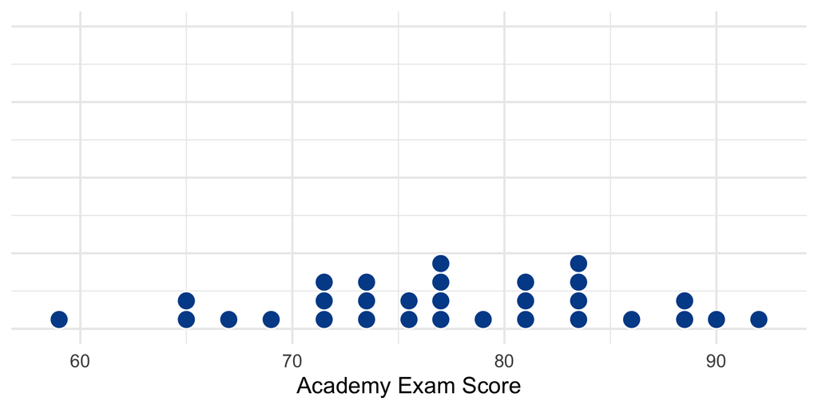

## Dot Plot (`R`)

Dot plot

A **dot plot** places one dot for every observation along a number line.

```r
dataset_name |>
  ggplot(aes(x = outcome_name)) +
  geom_dotplot()
```

**1**

`dataset_name` is the name of the dataset you are working with.

**2**

`ggplot()` is the function that creates a plot. The `aes()` function inside it tells R which variable to plot.

**3**

`geom_dotplot()` is the function that creates a dot plot.

## Histogram

Histogram

A **histogram** takes the same points and groups them into bins, showing how many values fall in each range.

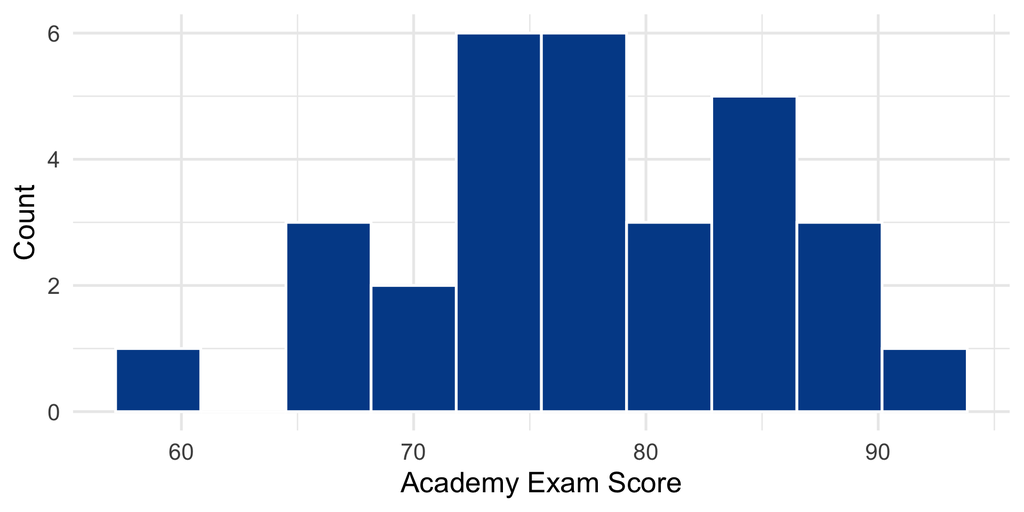

## Histogram (`R`)

Histogram

A **histogram** takes the same points and groups them into bins, showing how many values fall in each range.

```r
dataset_name |>
  ggplot(aes(x = outcome_name)) +
  geom_histogram(bins = number_of_bins)
```

**1**

`dataset_name` is the name of the dataset you are working with.

**2**

`ggplot()` is the function that creates a plot. The `aes()` function inside it tells R which variable to plot.

**3**

`geom_histogram()` is the function that creates a histogram.

## Density Plot

Density plot

A **density plot** is a histogram with the rough edges smoothed away.

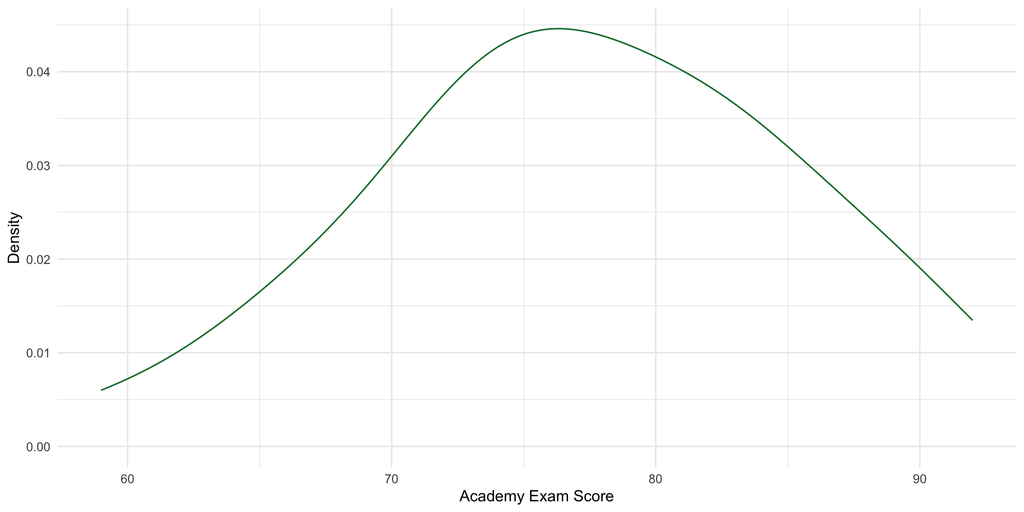

## Density Plot (`R`)

Density plot

A **density plot** is a histogram with the rough edges smoothed away.

```r
dataset_name |>
  ggplot(aes(x = outcome_name)) +
  geom_density()
```

**1**

`dataset_name` is the name of the dataset you are working with.

**2**

`ggplot()` is the function that creates a plot. The `aes()` function inside it tells R which variable to plot.

**3**

`geom_density()` is the function that creates a density plot

## Boxplot

Boxplot

A **boxplot** visualizes the five number summary: minimum, Q1, median, Q3, and maximum.

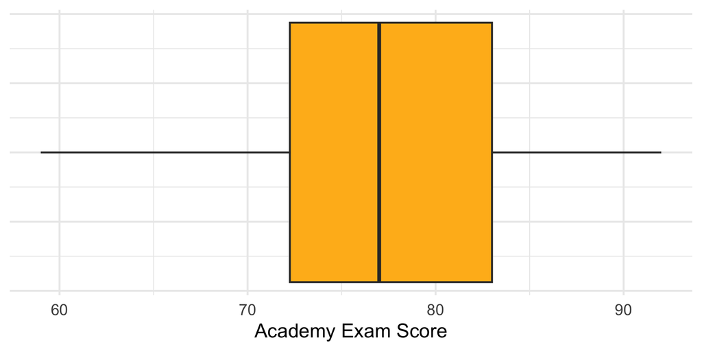

## Boxplot (`R`)

Boxplot

A **boxplot** visualizes the five number summary: minimum, Q1, median, Q3, and maximum.

```r
dataset_name |>
  ggplot(aes(x = outcome_name)) +
  geom_boxplot()
```

**1**

`dataset_name` is the name of the dataset you are working with.

**2**

`ggplot()` is the function that creates a plot. The `aes()` function inside it tells R which variable to plot.

**3**

`geom_boxplot()` is the function that creates a boxplot

## Scatterplot

Scatterplot

A **scatterplot** is a graph that shows the relationship between two continuous variables.

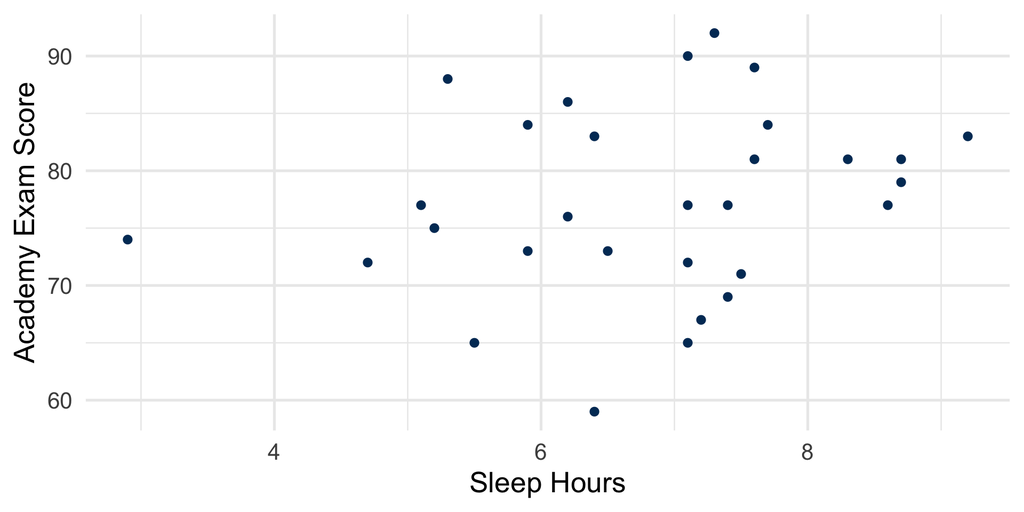

## Scatterplot (`R`)

Scatterplot

A **scatterplot** is a graph that shows the relationship between two continuous variables.

```r
dataset_name |>
  ggplot(aes(x = predictor_name, y = outcome_name)) +
  geom_point()
```

**1**

`dataset_name` is the name of the dataset you are working with.

**2**

`ggplot()` is the function that creates a plot. The `aes()` function inside it tells R which variable to plot.

**3**

`geom_point()` is the function that plots the points on the scatterplot.

## Example 1

- Deputy Chief Okonokwo is curious about the `hustle_earnings` data. He wants to know how much recruits are earning on the side.
- Our first task is to summarize the data.
  - Summary statistics.
  - Visualizations – check for weird patterns.
    - Dot plot
    - Histogram / density
    - Boxplot

## Example 1

- Our first step in any analysis should be to literally look at the data.
  - Note: we are printing the data below for slide/lecture purposes. In “real life,” we can open the dataset to examine.

| resident_name | department | district | hustle_earnings |
| --- | --- | --- | --- |
| Sable Jones | Desk | Rainforest District | 14.72 |
| Kevin Frostwhisker | Patrol | Downtown | 45.66 |
| Jasper Duskrunner | Patrol | Sahara Square | 30.91 |
| Greta Smith | Desk | Tundratown | 36.10 |
| Otto Meadowsly | Patrol | Downtown | 51.91 |
| Wilhelmina Underbrush | Desk | Rainforest District | 20.76 |

## Example 1

- Then, we look at the histogram/density plots:

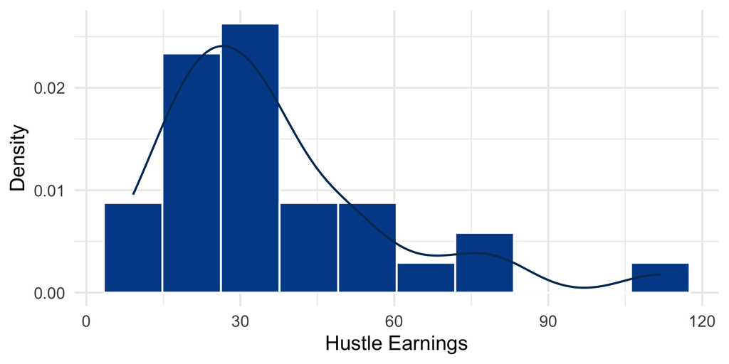

## Example 1 (Code)

- Then, we look at the histogram/density plots:

```r
zootopia |>
  ggplot(aes(x = hustle_earnings)) +
  geom_histogram(aes(y = after_stat(density)), fill = uwf_blue, color = "white", bins = 10) +
  geom_density(color = uwf_midnight, linewidth = 1) +
  labs(x = "Hustle Earnings",
       y = "Density") +
  theme_minimal(base_size = 20)
```

## Example 1

- Now, let’s look at the distribution of the data using a boxplot,

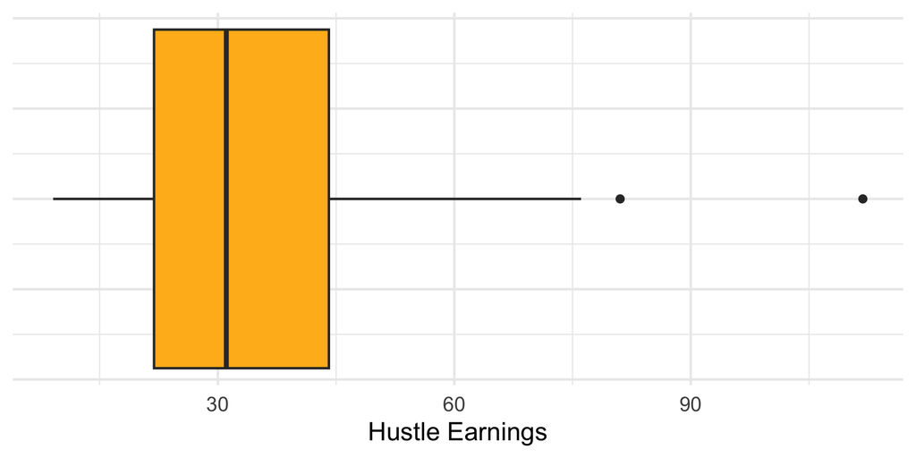

## Example 1 (Code)

- Now, let’s look at the distribution of the data using a boxplot,

```r
zootopia |>
  ggplot(aes(x = hustle_earnings)) +
  geom_boxplot(fill = uwf_marigold) +
  labs(x = "Hustle Earnings") +
  theme_minimal(base_size = 20) +
  theme(axis.text.y = element_blank())
```

## Example 1

- We can also split the box plots by district,

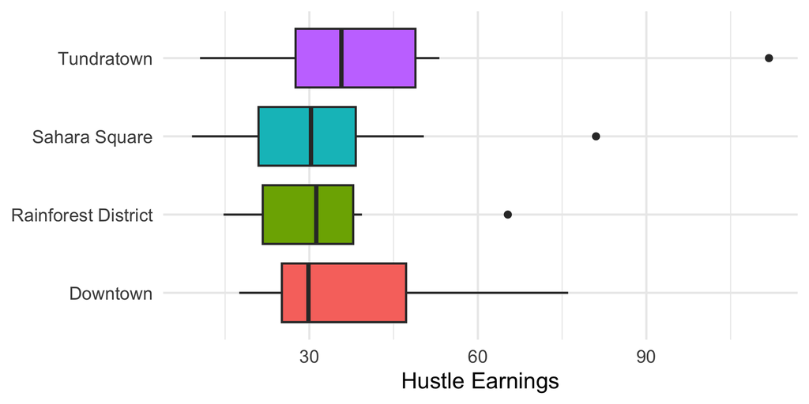

## Example 1 (Code)

- We can also split the box plots by district,

```r
zootopia |>
  ggplot(aes(x = hustle_earnings, y = district, fill = district)) +
  geom_boxplot() +
  labs(x = "Hustle Earnings", y = NULL) +
  theme_minimal(base_size = 20) +
  theme(legend.position = "none")
```

## Example 1

- The boxplot confirms that there are extreme values.
- Exploring the extreme values,

```r
zootopia |>
  select(resident_name, department, district, hustle_earnings) |>
  filter(hustle_earnings > 80)
```

| resident_name | department | district | hustle_earnings |
| --- | --- | --- | --- |
| Barnaby Frostwhisker | Desk | Tundratown | 111.83 |
| Nadia Trunkston | Patrol | Sahara Square | 81.04 |

## Example 1

- Now, we can find the descriptive statistics. That requires `mean_median()`,

```r
zootopia |>
  mean_median(hustle_earnings)
```

```
# A tibble: 1 × 3
  variable        mean_sd     median_iqr
  <chr>           <chr>       <chr>
1 hustle_earnings 36.7 (22.8) 31.1 (22.2)
```

- The difference between the mean and median suggests the data is skewed, as we saw with the histogram.
- The overall mean is helpful, but we should look at this more granularly to give the city better information.

## Example 1

- Let’s now find the descriptive statistics by district. That requires `mean_median()`, but now we add in `group_by()`,

```r
zootopia |>
  group_by(district) |>
  mean_median(hustle_earnings)
```

```
# A tibble: 4 × 4
  district            variable        mean_sd     median_iqr
  <chr>               <chr>           <chr>       <chr>
1 Downtown            hustle_earnings 37.3 (19.6) 29.8 (22.1)
2 Rainforest District hustle_earnings 32.9 (16.8) 31.2 (16.1)
3 Sahara Square       hustle_earnings 33.4 (21.6) 30.3 (17.3)
4 Tundratown          hustle_earnings 45.3 (35.5) 35.7 (21.3)
```

## Visualizing the Summary Statistics

- Until now, we’ve focused on describing the *entire distribution* of a variable.
- Sometimes, we want to communicate just a single number (e.g., mean) and how much to trust it.
  - We will graph a single value with a range around it showing uncertainty or spread.
- We have two choices to show the uncertainty:
  - Standard deviation
    - This is the spread of the data around the mean.
  - Standard error
    - This describes how precise the estimate of the mean is.

## Standard Error

Standard error

**Standard error (SE)** describes how *precise* the estimate of the mean is

$$\text{SE} = \frac{\text{SD}}{\sqrt{n}}$$

- This is the standard deviation adjusted for the sample size.

## Visualizing the Mean

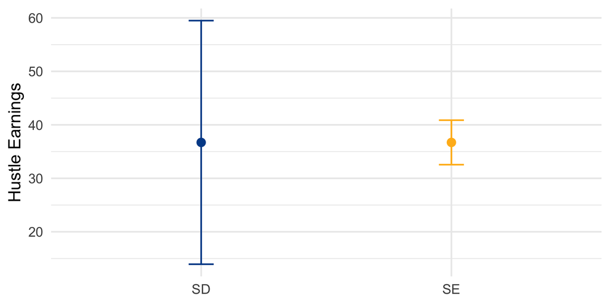

## Visualizing the Mean

- Finally, we can of course, split this out by district,

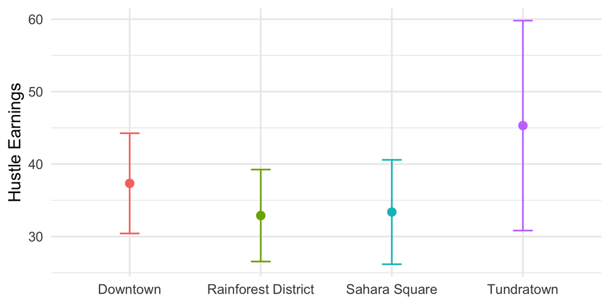

## Visualizing the Mean

- Some notes from a professional point of view:
  - Some folks like to use bar graphs to represent the mean. This is inaccurate.
  - How to choose between using SD and SE? I always use SE.
    - Preview for the next module: the SE is used in the calculation of confidence intervals.

## Wrap Up

- We have covered basics for describing and visualizing continuous variables.
  - Center:
    - Mean
    - Median
    - Mode
  - Spread:
    - Variance
    - Standard deviation
    - (Standard error)
    - Interquartile range